# Mesophotic_Database_release_2.0

Veronica Radice

10/18/2023

Code for the manuscript:

*“Recent trends and biases in mesophotic ecosystem research”*

Veronica Z. Radice, Alejandra Hernandez-Agreda, Gonzalo Pérez-Rosales, Ryan Booker, Jessica Bellworthy, Manon Broadribb, Gaby E. Carpenter, Clara Diaz, Ryan J. Eckert, Nicola L. Foster, Johanna C. Gijsbers, Erika Gress, Jack H Laverick, Valerio Micaroni, Miriam Pierotti, Héloïse Rouzé, Angela Stevenson, Alexis B. Sturm, Pim Bongaerts

*Biology Letters* (2024)

#### Load packages

```r
require(dplyr)
require(plyr)
require(tidyr)
require(ggplot2)
#require(ggstance)
require(ggpubr)
require(tidyverse)
require(cowplot)
library(RcppRoll)
library(ggridges)
```

##### Colorblind-friendly palette

```r
# http://www.cookbook-r.com/Graphs/Colors_(ggplot2)/
#cbPalette <- c("#999999", "#E69F00", "#56B4E9", "#009E73", "#F0E442", "#0072B2", "#D55E00", "#CC79A7")

library(viridis)

viridisPalette5 <- c("#440154FF", "#7AD151FF", "#414487FF", "#fde725FF", "#2A788EFF")

# "Fishes", "Macroalgae", "Octocorals", "Scleractinian Corals", "Sponges"
# dark purple #440154
# light green #5ec962 #7AD151FF
# dark blue #3b528b #414487FF
# yellow #fde725
# teal #21918c #2A788EFF
# #25858EFF
```

### Import the database directly from the *mesophotic.org* website into R

```r
# automatically download the current version of the database
#publs <- read.csv("http://www.mesophotic.org/publications.csv", as.is=TRUE)

setwd("~/Documents/Collaborations/Mesophotic.org")

# import static copy (up until & including the year 2023)
publs <- read.csv("publications_static_databaseRelease2.0.csv", as.is=TRUE)

# if importing from a directory on your computer
#publs <- read.csv("publications.csv", as.is=TRUE)

publs[sapply(publs, is.character)] <- lapply(publs[sapply(publs, is.character)], as.factor)

# when need to use year as factor
publs$year <- factor(publs$publication_year)

# keep this as integer (numeric)
#publs$publication_year <- factor(publs$publication_year)

dim(publs)
```

```
## [1] 1500   30
```

```r
colnames(publs)
```

```
##  [1] "id"                 "validated"          "included_in_stats"
##  [4] "publication_type"   "publication_format" "publication_year"
##  [7] "authors"            "title"              "journal_name"
## [10] "volume"             "issue"              "pages"
## [13] "doi"                "url"                "book_title"
## [16] "book_authors"       "book_publisher"     "pdf_present"
## [19] "mesophotic"         "mce"                "tme"
## [22] "original_data"      "new_species"        "min_depth"
## [25] "max_depth"          "fields"             "focusgroups"
## [28] "platforms"          "locations"          "year"
```

Summary of publication formats

```
## # A tibble: 5 × 2
##   publication_format count
##   <fct>              <int>
## 1 article             1330
## 2 chapter              101
## 3 report                28
## 4 review                34
## 5 thesis                 7
```

Summary of publication types

```r
publs %>%
  group_by(publication_type) %>%
   dplyr::summarise(count=n())
```

```
## # A tibble: 3 × 2
##   publication_type count
##   <fct>            <int>
## 1 popular              7
## 2 scientific        1465
## 3 technical           28
```

Overall summary of different types of publications

```r
publs %>%
  group_by(publication_type, publication_format) %>%
   dplyr::summarise(count=n())
```

```
## # A tibble: 7 × 3
## # Groups:   publication_type [3]
##   publication_type publication_format count
##   <fct>            <fct>              <int>
## 1 popular          article                5
## 2 popular          review                 2
## 3 scientific       article             1325
## 4 scientific       chapter              101
## 5 scientific       review                32
## 6 scientific       thesis                 7
## 7 technical        report                28
```

Summary of validated publications

```r
publs %>%
  filter(publication_type == "scientific" & publication_format == "article" | publication_format == "chapter") %>%
    group_by(publication_type, publication_format, validated) %>%
      dplyr::summarise(count=n())
```

```
## # A tibble: 4 × 4
## # Groups:   publication_type, publication_format [2]
##   publication_type publication_format validated count
##   <fct>            <fct>              <lgl>     <int>
## 1 scientific       article            FALSE         9
## 2 scientific       article            TRUE       1316
## 3 scientific       chapter            FALSE        30
## 4 scientific       chapter            TRUE         71
```

*validated = FALSE scientific articles are typically early (older) papers that are missing both abstract and full text, and thus metadata cannot be entered (nor validated)*

Years with top publication counts *Interesting peak during international coral reef conference (ICRS) in 2016 and 2021*

```r
publs %>%
  filter(publication_type == "scientific" & publication_format == "article") %>%
    group_by(year) %>%
      dplyr::summarise(count=n()) %>%
          arrange(desc(count)) %>%
            head()
```

```
## # A tibble: 6 × 2
##   year  count
##   <fct> <int>
## 1 2016    113
## 2 2021    110
## 3 2020    104
## 4 2019     94
## 5 2018     88
## 6 2022     88
```

#### Long-term monitoring (articles and reports) - by focusgroups

```r
publs_LTM_fields <- publs %>%
  filter(grepl("Long-term monitoring", fields))

publs_LTM_fields %>%
  #filter(fields == "Long-term monitoring") %>%
    group_by(publication_format) %>%
      dplyr::summarise(count=n()) %>%
        #top_n(10, count) %>%
          arrange(desc(count))
```

```
## # A tibble: 4 × 2
##   publication_format count
##   <fct>              <int>
## 1 article               72
## 2 chapter               14
## 3 report                 5
## 4 review                 3
```

```r
# articles and reports only
publs_LTM_fields <- publs_LTM_fields %>%
  filter(publication_format != "review" & publication_format != "chapter")
```

```r
# Split `locations` into new rows
publs_LTM_fields_locations <- separate_rows(publs_LTM_fields, "locations", sep=";\\s+")

# Remove rows with no associated `locations`
publs_LTM_fields_locations <- publs_LTM_fields_locations[!
(is.na(publs_LTM_fields_locations$locations) |
publs_LTM_fields_locations$locations ==
""), ]

publs_LTM_fields_locations$locations <- factor(publs_LTM_fields_locations$locations)

publs_LTM_fields_locations %>%
    group_by(locations, publication_format) %>%
      dplyr::summarise(count=n()) %>%
        arrange(desc(count))
```

```
## # A tibble: 41 × 3
## # Groups:   locations [32]
##    locations                      publication_format count
##    <fct>                          <fct>              <int>
##  1 Israel - Red Sea               article               12
##  2 US Virgin Islands              article                9
##  3 Curaçao                        article                7
##  4 USA - Gulf of Mexico           article                6
##  5 Bonaire                        article                5
##  6 Spain - Mediterranean Sea      article                5
##  7 US Virgin Islands              report                 4
##  8 USA - Pulley Ridge             article                4
##  9 Australia - Great Barrier Reef article                3
## 10 Bahamas                        article                3
## # ℹ 31 more rows
```

```r
# Split `fields` into new rows
publs_LTM_fields <- separate_rows(publs_LTM_fields, "fields", sep=";\\s+")

# Remove rows with no associated `fields`
publs_LTM_fields <- publs_LTM_fields[!
(is.na(publs_LTM_fields$fields) |
publs_LTM_fields$fields ==
""), ]

publs_LTM_fields$fields <- factor(publs_LTM_fields$fields)
```

Look at what other fields are studied in publications with Long-term monitoring tag

```r
publs_LTM_fields %>%
    group_by(fields) %>%
      dplyr::summarise(count=n()) %>%
        #top_n(10, count) %>%
          arrange(desc(count))
```

```
## # A tibble: 22 × 2
##    fields                      count
##    <fct>                       <int>
##  1 Long-term monitoring           77
##  2 Ecology                        44
##  3 Community structure            29
##  4 Disturbances                   22
##  5 Physiology                     20
##  6 Biodiversity                   14
##  7 Management and Conservation    13
##  8 Oceanography                   13
##  9 Climate Change                 10
## 10 Connectivity                    9
## # ℹ 12 more rows
```

Look at what focusgroups are studied in publications with Long-term monitoring

```r
publs_LTM_focusgroups <- publs %>%
  filter(grepl("Long-term monitoring", fields))

publs_LTM_focusgroups <- publs_LTM_focusgroups %>%
  filter(publication_format != "review" & publication_format != "chapter")

# Split `focusgroups` into new rows
publs_LTM_focusgroups <- separate_rows(publs_LTM_focusgroups, "focusgroups", sep=";\\s+")

# Remove rows with no associated `focusgroups`
publs_LTM_focusgroups <- publs_LTM_focusgroups[!
(is.na(publs_LTM_focusgroups$focusgroups) |
publs_LTM_focusgroups$focusgroups ==
""), ]

publs_LTM_focusgroups$focusgroups <- factor(publs_LTM_focusgroups$focusgroups)

publs_LTM_focusgroups %>%
    group_by(focusgroups) %>%
      dplyr::summarise(count=n()) %>%
        #top_n(10, count) %>%
          arrange(desc(count))
```

```
## # A tibble: 19 × 2
##    focusgroups                                count
##    <fct>                                      <int>
##  1 Scleractinia (Hard Corals)                    43
##  2 Fishes                                        23
##  3 Octocorallia (Soft Corals)                    16
##  4 Overall benthic (groups)                      16
##  5 Algae (Macro, Turf and Crustose Coralline)    11
##  6 Symbiodinium (zooxanthellae)                  11
##  7 Other invertebrates                           10
##  8 Porifera (Sponges)                             8
##  9 Antipatharia (Black Corals)                    7
## 10 Crustacea                                      4
## 11 Hydrozoa                                       3
## 12 Seagrass                                       3
## 13 Actiniaria and Ceriantharia (Sea anemones)     2
## 14 Bacteria and Archaea                           2
## 15 Zoantharia (Zoanthids)                         2
## 16 Marine mammals                                 1
## 17 Other endosymbionts (non-Symbiodinium)         1
## 18 Plankton                                       1
## 19 Viruses                                        1
```

### Technical reports

```r
reports <- subset(publs, publication_type == "technical")
```

```r
# Split `locations` into new rows
reports_locations <- separate_rows(reports, "locations", sep=";\\s+")

# Remove rows with no associated `locations`
reports_locations <- reports_locations[!
(is.na(reports_locations$locations) |
reports_locations$locations ==
""), ]

reports_locations$locations <- factor(reports_locations$locations)
```

##### Locations of reports

```r
reports_locations %>%
    group_by(locations) %>%
      dplyr::summarise(count=n()) %>%
        arrange(desc(count))
```

```
## # A tibble: 19 × 2
##    locations                               count
##    <fct>                                   <int>
##  1 Puerto Rico                                 6
##  2 US Virgin Islands                           6
##  3 USA - Hawaii                                5
##  4 USA - Continental Atlantic Ocean            4
##  5 USA - Continental Pacific Ocean             4
##  6 USA - Gulf of Mexico                        4
##  7 Australia - Great Barrier Reef              3
##  8 American Samoa                              2
##  9 Australia - Western Australia               2
## 10 Japan - Ryukyu Islands (Okinawa)            2
## 11 Micronesia - Guam                           2
## 12 Micronesia - Mariana Islands                2
## 13 Australia - Northern Australia              1
## 14 Australia - Southeastern Australia          1
## 15 Bermuda                                     1
## 16 Chagos Archipelago                          1
## 17 Israel - Red Sea                            1
## 18 Micronesia - Caroline Islands (Pohnpei)     1
## 19 USA - Pulley Ridge                          1
```

### Select only “Scientific” “Article” (original research)

Moving forward with analyses

```r
publs <- subset(publs, publication_type == "scientific" & publication_format == "article")
publs <- droplevels(publs)
```

### Select validated publications

Subset the publication list to those that are validated (i.e., metadata validated by two different content editors) and those that are included_in_stats (i.e., as validated but only including publications representing (peer-reviewed) scientific articles presenting original data from mesophotic depths):

```r
# use validated == "true" for file obtained directly from website,
# or validated == "TRUE" for static downloaded CSV file
# same for included_in_stats variable
publs <- subset(publs, validated == "TRUE") #publs_validated
publs <- subset(publs, included_in_stats == "TRUE") #publs_for_stats # Original data
```

##### Consider MCE and TME separately

MCE

```r
publs.mce <- subset(publs, mce == "TRUE") #mce == "true"
publs.mce <- droplevels(publs.mce)
dim(publs.mce)
```

```
## [1] 836  30
```

TME

```r
publs.tme <- subset(publs, tme == "TRUE") #tme == "true"
publs.tme <- droplevels(publs.tme)
dim(publs.tme)
```

```
## [1] 297  30
```

# Data analysis

## Change in publication numbers over time

Calculate the fold-increase in publications From 2008 to 2023

```r
publs_time_counts <- publs %>% #publs_validated
  group_by(publication_year) %>%
    dplyr::summarise(count=n()) %>%
      mutate(total_count = cumsum(count))

total_count <- publs_time_counts[publs_time_counts$publication_year==2023, "total_count"]/publs_time_counts[publs_time_counts$publication_year==2008, "total_count"]

total_count
```

```
##   total_count
## 1    4.753846
```

MCE specific

```r
publs_time_counts <- publs.mce %>% #publs_validated
  group_by(publication_year) %>%
    dplyr::summarise(count=n()) %>%
      mutate(total_count = cumsum(count))

total_count <- publs_time_counts[publs_time_counts$publication_year==2023, "total_count"]/publs_time_counts[publs_time_counts$publication_year==2008, "total_count"]

total_count
```

```
##   total_count
## 1    4.201005
```

TME specific

```r
publs_time_counts <- publs.tme %>% #publs_validated
  group_by(publication_year) %>%
    dplyr::summarise(count=n()) %>%
      mutate(total_count = cumsum(count))

total_count <- publs_time_counts[publs_time_counts$publication_year==2023, "total_count"]/publs_time_counts[publs_time_counts$publication_year==2008, "total_count"]

total_count
```

```
##   total_count
## 1        6.75
```

### Publications by focus groups

Where fields have multiple values (through so-called “HABTM” associations), such as research_fields , they are separated by semicolons, for example: Ecology; Community structure; Disturbances.

Therefore, to query any of these fields, we need to separate these into individual rows. Then, we can plot for example the number of publications for each of those fields.

```r
# Split `focusgroups` into new rows
publs_focusgroups <- separate_rows(publs, "focusgroups", sep=";\\s+") #publs_for_stats

# Remove rows with no associated `focusgroups`
publs_focusgroups <- publs_focusgroups[!
(is.na(publs_focusgroups$focusgroups) |
publs_focusgroups$focusgroups ==
""), ]

publs_focusgroups$focusgroups <- factor(publs_focusgroups$focusgroups)
```

144 publications (scientific articles) with new species *Scleractinia (Hard Corals) 3 articles, for a total of 4 new species*

```r
publs_focusgroups %>%
  filter(new_species == "TRUE") %>% #new_species == "true"
    group_by(focusgroups, publication_format) %>%
      dplyr::summarise(count=n()) %>%
        arrange(desc(count))
```

```
## # A tibble: 11 × 3
## # Groups:   focusgroups [11]
##    focusgroups                                publication_format count
##    <fct>                                      <fct>              <int>
##  1 Fishes                                     article               54
##  2 Algae (Macro, Turf and Crustose Coralline) article               24
##  3 Crustacea                                  article               16
##  4 Porifera (Sponges)                         article               13
##  5 Other invertebrates                        article               12
##  6 Octocorallia (Soft Corals)                 article               11
##  7 Antipatharia (Black Corals)                article                6
##  8 Scleractinia (Hard Corals)                 article                3
##  9 Zoantharia (Zoanthids)                     article                3
## 10 Hydrozoa                                   article                1
## 11 Overall benthic (groups)                   article                1
```

Overall count of focus groups

```r
publs_focusgroups %>%
    group_by(focusgroups) %>%
      dplyr::summarise(count=n()) %>%
        #top_n(10, count) %>%
          arrange(desc(count))
```

```
## # A tibble: 21 × 2
##    focusgroups                                count
##    <fct>                                      <int>
##  1 Scleractinia (Hard Corals)                   356
##  2 Fishes                                       316
##  3 Overall benthic (groups)                     282
##  4 Octocorallia (Soft Corals)                   158
##  5 Algae (Macro, Turf and Crustose Coralline)   146
##  6 Porifera (Sponges)                           127
##  7 Other invertebrates                           91
##  8 Symbiodinium (zooxanthellae)                  86
##  9 Antipatharia (Black Corals)                   60
## 10 Crustacea                                     39
## # ℹ 11 more rows
```

```r
publs_focusgroups_counts <- publs_focusgroups %>%
     group_by(focusgroups, publication_year) %>%
      dplyr::summarise(count=n()) %>%
        arrange(desc(count))
```

#### Corals vs. Fishes vs. Octocorals

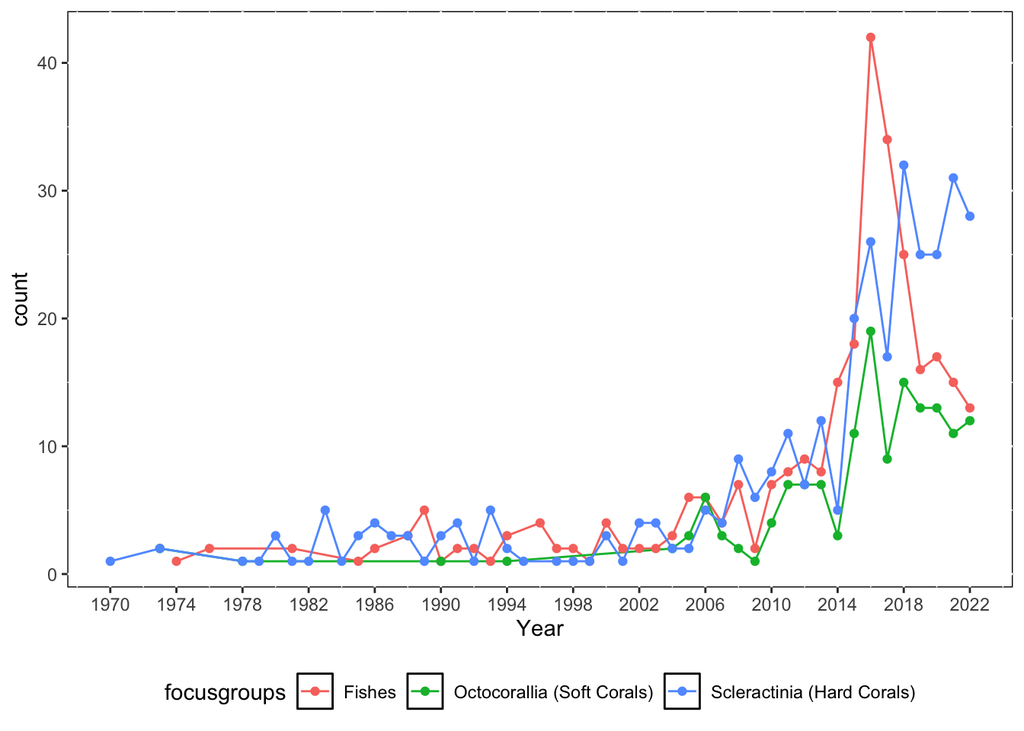

```r
publs_focusgroups_counts %>%
  filter(focusgroups == "Scleractinia (Hard Corals)" | focusgroups == "Fishes" | focusgroups == "Octocorallia (Soft Corals)") %>% #
    ggplot(aes(x=publication_year, y=count, color = focusgroups)) +
      geom_line() +
        geom_point() +
          #geom_area(colour="black", size=.3, alpha=.4, position = "identity") +
           scale_x_continuous(name = "Year", breaks = seq(1970, 2022, 4), limits = c(1970, 2022)) + #breaks = seq(1970, 2022, 4), limits = c(1970, 2022)
            #scale_y_continuous(limits = c(0,15), breaks = c(0,2,4,6,8,10,12,14)) +
            theme(panel.background = element_rect(fill = "white", colour = "black"), legend.position= "bottom")
```

## Publications by ‘Fields’

```r
# Split `fields` into new rows
publs_fields <- separate_rows(publs, "fields", sep=";\\s+") #publs_for_stats

# Remove rows with no associated `fields`
publs_fields <- publs_fields[!
(is.na(publs_fields$fields) |
publs_fields$fields ==
""), ]

publs_fields$fields <- factor(publs_fields$fields)
```

```r
publs_fields %>%
    group_by(fields) %>%
      dplyr::summarise(count=n()) %>%
        #top_n(10, count) %>%
          arrange(desc(count))
```

```
## # A tibble: 22 × 2
##    fields                      count
##    <fct>                       <int>
##  1 Biodiversity                  527
##  2 Ecology                       469
##  3 Community structure           424
##  4 Taxonomy                      190
##  5 Molecular ecology             159
##  6 Physiology                    158
##  7 Management and Conservation   133
##  8 Geomorphology                 122
##  9 Disturbances                  117
## 10 Connectivity                   96
## # ℹ 12 more rows
```

```r
publs_fields %>%
  filter(fields == "Taxonomy") %>%
    group_by(publication_year) %>%
      dplyr::summarise(count=n()) %>%
        arrange(desc(count)) %>%
          head()
```

```
## # A tibble: 6 × 2
##   publication_year count
##              <int> <int>
## 1             2016    18
## 2             2020    16
## 3             2017    12
## 4             2018    12
## 5             2019    12
## 6             2013    11
```

```r
publs_fields %>%
  filter(fields == "Physiology") %>%
    group_by(publication_year) %>%
      dplyr::summarise(count=n()) %>%
        arrange(desc(count)) %>%
          head()
```

```
## # A tibble: 6 × 2
##   publication_year count
##              <int> <int>
## 1             2023    14
## 2             2016    12
## 3             2021    12
## 4             2019    11
## 5             2022    11
## 6             2020    10
```

```r
publs_fields %>%
  filter(fields == "Molecular ecology") %>%
    group_by(publication_year) %>%
      dplyr::summarise(count=n()) %>%
        arrange(desc(count)) %>%
          head()
```

```
## # A tibble: 6 × 2
##   publication_year count
##              <int> <int>
## 1             2021    18
## 2             2022    17
## 3             2020    15
## 4             2023    15
## 5             2016    14
## 6             2018    12
```

```r
publs_fields %>%
  filter(fields == "Management and Conservation") %>%
    group_by(publication_year) %>%
      dplyr::summarise(count=n()) %>%
        arrange(desc(count)) %>%
          head()
```

```
## # A tibble: 6 × 2
##   publication_year count
##              <int> <int>
## 1             2018    16
## 2             2016    13
## 3             2017    12
## 4             2015    11
## 5             2020    10
## 6             2022    10
```

```r
publs_fields %>%
  filter(fields == "Geomorphology") %>%
    group_by(publication_year) %>%
      dplyr::summarise(count=n()) %>%
        arrange(desc(count)) %>%
          head()
```

```
## # A tibble: 6 × 2
##   publication_year count
##              <int> <int>
## 1             2016    10
## 2             2022    10
## 3             2015     9
## 4             2012     8
## 5             2014     8
## 6             2023     8
```

```r
publs_fields %>%
  filter(fields == "Disturbances") %>%
    group_by(publication_year) %>%
      dplyr::summarise(count=n()) %>%
        arrange(desc(count)) %>%
          head()
```

```
## # A tibble: 6 × 2
##   publication_year count
##              <int> <int>
## 1             2018    13
## 2             2021    13
## 3             2015    10
## 4             2017     8
## 5             2023     8
## 6             2019     7
```

```r
publs_fields %>%
  filter(fields == "Reproduction") %>%
    group_by(publication_year) %>%
      dplyr::summarise(count=n()) %>%
        arrange(desc(count)) %>%
          head()
```

```
## # A tibble: 6 × 2
##   publication_year count
##              <int> <int>
## 1             2021    11
## 2             2016     8
## 3             2018     6
## 4             2015     5
## 5             2005     3
## 6             2013     3
```

Within Fields, split focusgroups

```r
# Split `fields` into new rows
publs_fields_focusgroups <- separate_rows(publs_fields, "focusgroups", sep=";\\s+") #publs_for_stats

# Remove rows with no associated `fields`
publs_fields_focusgroups <- publs_fields_focusgroups[!
(is.na(publs_fields_focusgroups$fields) |
publs_fields_focusgroups$fields ==
""), ]

publs_fields_focusgroups$focusgroups <- factor(publs_fields_focusgroups$focusgroups)
```

```r
publs_fields_focusgroups %>%
  filter(fields == "Taxonomy") %>%
    group_by(focusgroups) %>%
      dplyr::summarise(count=n()) %>%
        arrange(desc(count))
```

```
## # A tibble: 14 × 2
##    focusgroups                                count
##    <fct>                                      <int>
##  1 Fishes                                        56
##  2 Algae (Macro, Turf and Crustose Coralline)    36
##  3 Crustacea                                     20
##  4 Porifera (Sponges)                            19
##  5 Other invertebrates                           16
##  6 Octocorallia (Soft Corals)                    15
##  7 Antipatharia (Black Corals)                   13
##  8 Scleractinia (Hard Corals)                     8
##  9 Zoantharia (Zoanthids)                         4
## 10 Overall benthic (groups)                       3
## 11 Fungi                                          1
## 12 Hydrozoa                                       1
## 13 Seagrass                                       1
## 14 Symbiodinium (zooxanthellae)                   1
```

```r
publs_fields_focusgroups %>%
  filter(fields == "Taxonomy") %>%
    group_by(focusgroups, new_species) %>%
      dplyr::summarise(count=n()) %>%
        arrange(desc(count))
```

```
## # A tibble: 23 × 3
## # Groups:   focusgroups [14]
##    focusgroups                                new_species count
##    <fct>                                      <lgl>       <int>
##  1 Fishes                                     TRUE           54
##  2 Algae (Macro, Turf and Crustose Coralline) TRUE           24
##  3 Crustacea                                  TRUE           16
##  4 Porifera (Sponges)                         TRUE           13
##  5 Algae (Macro, Turf and Crustose Coralline) FALSE          12
##  6 Other invertebrates                        TRUE           12
##  7 Octocorallia (Soft Corals)                 TRUE           10
##  8 Antipatharia (Black Corals)                FALSE           7
##  9 Antipatharia (Black Corals)                TRUE            6
## 10 Porifera (Sponges)                         FALSE           6
## # ℹ 13 more rows
```

```r
publs_fields_focusgroups %>%
  filter(fields == "Physiology") %>%
    group_by(focusgroups) %>%
      dplyr::summarise(count=n()) %>%
        #top_n(10, count) %>%
          arrange(desc(count))
```

```
## # A tibble: 15 × 2
##    focusgroups                                count
##    <fct>                                      <int>
##  1 Scleractinia (Hard Corals)                   109
##  2 Symbiodinium (zooxanthellae)                  62
##  3 Algae (Macro, Turf and Crustose Coralline)    14
##  4 Octocorallia (Soft Corals)                    13
##  5 Porifera (Sponges)                            12
##  6 Fishes                                        11
##  7 Antipatharia (Black Corals)                    6
##  8 Bacteria and Archaea                           6
##  9 Other endosymbionts (non-Symbiodinium)         5
## 10 Overall benthic (groups)                       4
## 11 Other invertebrates                            3
## 12 Plankton                                       2
## 13 Actiniaria and Ceriantharia (Sea anemones)     1
## 14 Protists (non-Symbiodiniaceae)                 1
## 15 Zoantharia (Zoanthids)                         1
```

```r
publs_fields_focusgroups %>%
  filter(fields == "Connectivity") %>%
    group_by(focusgroups) %>%
      dplyr::summarise(count=n()) %>%
        #top_n(10, count) %>%
          arrange(desc(count))
```

```
## # A tibble: 15 × 2
##    focusgroups                                  count
##    <fct>                                        <int>
##  1 "Scleractinia (Hard Corals)"                    53
##  2 "Symbiodinium (zooxanthellae)"                  18
##  3 "Fishes"                                        17
##  4 "Octocorallia (Soft Corals)"                    17
##  5 "Algae (Macro, Turf and Crustose Coralline)"     9
##  6 "Overall benthic (groups)"                       7
##  7 "Porifera (Sponges)"                             5
##  8 "Antipatharia (Black Corals)"                    4
##  9 "Crustacea"                                      4
## 10 "Hydrozoa"                                       3
## 11 "Other invertebrates"                            2
## 12 ""                                               1
## 13 "Actiniaria and Ceriantharia (Sea anemones)"     1
## 14 "Bacteria and Archaea"                           1
## 15 "Zoantharia (Zoanthids)"                         1
```

```r
publs_fields_focusgroups %>%
  filter(focusgroups == "Scleractinia (Hard Corals)" | focusgroups == "Fishes" | focusgroups ==  "Symbiodinium (zooxanthellae)") %>%
    group_by(focusgroups, fields) %>%
      dplyr::summarise(count=n()) %>%
        #top_n(10, count) %>%
          arrange(desc(count))
```

```
## # A tibble: 56 × 3
## # Groups:   focusgroups [3]
##    focusgroups                  fields              count
##    <fct>                        <fct>               <int>
##  1 Fishes                       Biodiversity          167
##  2 Fishes                       Ecology               141
##  3 Scleractinia (Hard Corals)   Ecology               141
##  4 Fishes                       Community structure   132
##  5 Scleractinia (Hard Corals)   Community structure   123
##  6 Scleractinia (Hard Corals)   Physiology            109
##  7 Scleractinia (Hard Corals)   Biodiversity           92
##  8 Scleractinia (Hard Corals)   Molecular ecology      75
##  9 Symbiodinium (zooxanthellae) Physiology             62
## 10 Fishes                       Fisheries              60
## # ℹ 46 more rows
```

All fields

```r
publs_fields %>%
    group_by(fields) %>%
      dplyr::summarise(count=n()) %>%
        #top_n(10, count) %>%
          arrange(desc(count))
```

```
## # A tibble: 22 × 2
##    fields                      count
##    <fct>                       <int>
##  1 Biodiversity                  527
##  2 Ecology                       469
##  3 Community structure           424
##  4 Taxonomy                      190
##  5 Molecular ecology             159
##  6 Physiology                    158
##  7 Management and Conservation   133
##  8 Geomorphology                 122
##  9 Disturbances                  117
## 10 Connectivity                   96
## # ℹ 12 more rows
```

Emerging fields

```r
publs_fields %>%
  filter(fields == "Connectivity" | fields == "Taxonomy" | fields == "Management and Conservation" | fields == "Physiology" | fields == "Geomorphology" | fields == "Disturbances" | fields == "Reproduction" | fields == "Molecular ecology" | fields == "Long-term monitoring") %>%
    group_by(fields) %>%
      dplyr::summarise(count=n()) %>%
        #top_n(10, count) %>%
          arrange(desc(count))
```

```
## # A tibble: 9 × 2
##   fields                      count
##   <fct>                       <int>
## 1 Taxonomy                      190
## 2 Molecular ecology             159
## 3 Physiology                    158
## 4 Management and Conservation   133
## 5 Geomorphology                 122
## 6 Disturbances                  117
## 7 Connectivity                   96
## 8 Long-term monitoring           65
## 9 Reproduction                   57
```

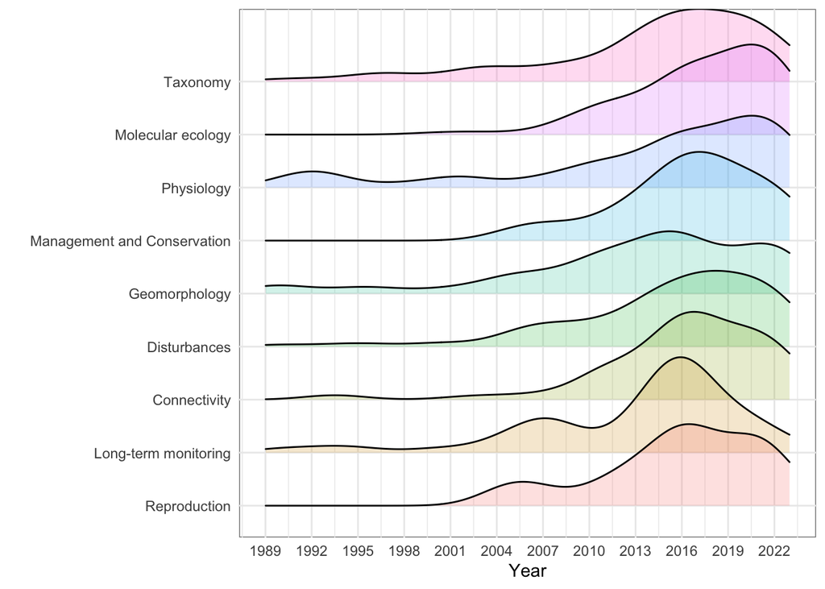

```r
# publs_fields$fields <- factor(publs_fields$fields, levels = c("Biodiversity", "Physiology", "Molecular ecology", "Management and Conservation", "Geomorphology", "Disturbances", "Connectivity", "Reproduction"))

publs_fields$fields <- factor(publs_fields$fields, levels = c("Reproduction", "Long-term monitoring", "Connectivity", "Disturbances", "Geomorphology", "Management and Conservation", "Physiology", "Molecular ecology", "Taxonomy"))

ridgeplot_fields <- publs_fields %>%
  filter(fields == "Taxonomy" | fields == "Molecular ecology" | fields == "Physiology" | fields == "Management and Conservation" | fields == "Geomorphology" | fields == "Disturbances" | fields == "Connectivity" | fields == "Long-term monitoring" | fields == "Reproduction") %>%  #fields ==  "Biodiversity" |
  ggplot(aes(x=publication_year, y=fields, fill = fields)) +
    geom_density_ridges(alpha = 0.2) +
    scale_x_continuous(name = "Year", breaks = seq(1989, 2023, 3), limits = c(1989, 2023)) +
    xlab("Year") +
    ylab("") +
    theme_minimal() +
    theme(panel.background = element_rect(colour = "grey50"), legend.position = "none")

ridgeplot_fields
```

alternate version b - with vertical line 2008 (to show last 15 years)

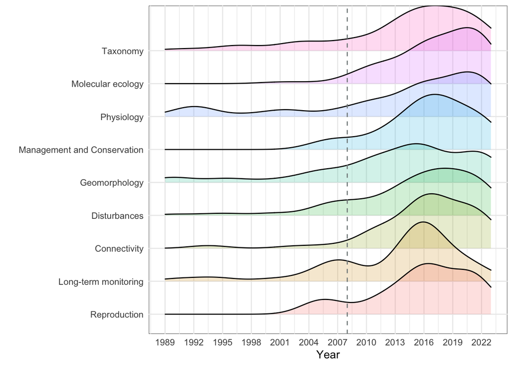

```r
# publs_fields$fields <- factor(publs_fields$fields, levels = c("Biodiversity", "Physiology", "Molecular ecology", "Management and Conservation", "Geomorphology", "Disturbances", "Connectivity", "Reproduction"))

publs_fields$fields <- factor(publs_fields$fields, levels = c("Reproduction", "Long-term monitoring", "Connectivity", "Disturbances", "Geomorphology", "Management and Conservation", "Physiology", "Molecular ecology", "Taxonomy"))

ridgeplot_fields_b <- publs_fields %>%
  filter(fields == "Taxonomy" | fields == "Molecular ecology" | fields == "Physiology" | fields == "Management and Conservation" | fields == "Geomorphology" | fields == "Disturbances" | fields == "Connectivity" | fields == "Long-term monitoring" | fields == "Reproduction") %>%  #fields ==  "Biodiversity" |
  ggplot(aes(x=publication_year, y=fields, fill = fields)) +
    geom_density_ridges(alpha = 0.2) +
    geom_vline(xintercept = 2008, linetype = 2, colour = "azure4", alpha = 1) +
    scale_x_continuous(name = "Year", breaks = seq(1989, 2023, 3), limits = c(1989, 2023)) +
    xlab("Year") +
    ylab("") +
    theme_minimal() +
    theme(panel.background = element_rect(colour = "grey50"), legend.position = "none")

ridgeplot_fields_b
```

alternate version c - with histograms

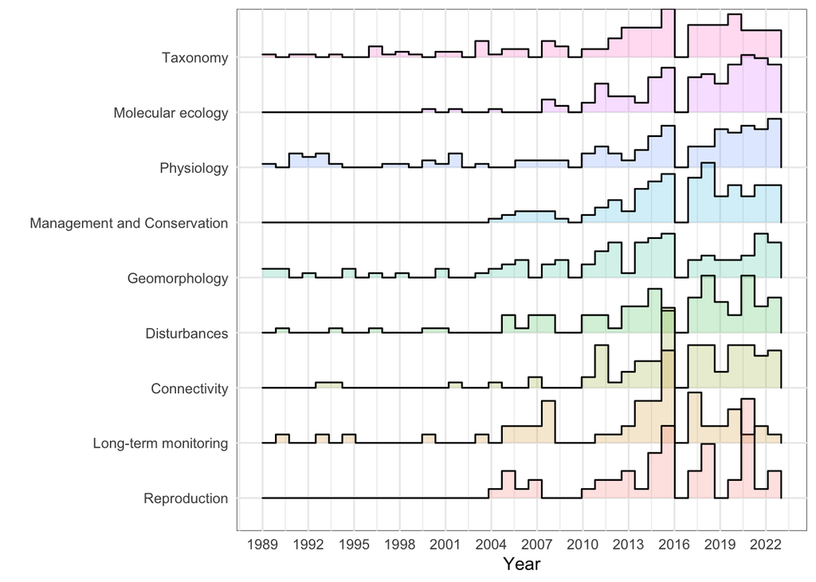

```r
# publs_fields$fields <- factor(publs_fields$fields, levels = c("Biodiversity", "Physiology", "Molecular ecology", "Management and Conservation", "Geomorphology", "Disturbances", "Connectivity", "Reproduction"))

publs_fields$fields <- factor(publs_fields$fields, levels = c("Reproduction", "Long-term monitoring", "Connectivity", "Disturbances", "Geomorphology", "Management and Conservation", "Physiology", "Molecular ecology", "Taxonomy"))

ridgeplot_fields_c <- publs_fields %>%
  filter(fields == "Taxonomy" | fields == "Molecular ecology" | fields == "Physiology" | fields == "Management and Conservation" | fields == "Geomorphology" | fields == "Disturbances" | fields == "Connectivity" | fields == "Long-term monitoring" | fields == "Reproduction") %>%  #fields ==  "Biodiversity" |
  ggplot(aes(x=publication_year, y=fields, fill = fields)) +
    geom_density_ridges(alpha = 0.2, stat="binline", bins=40) +
    scale_x_continuous(name = "Year", breaks = seq(1989, 2023, 3), limits = c(1989, 2023)) +
    xlab("Year") +
    ylab("") +
    theme_minimal() +
    theme(panel.background = element_rect(colour = "grey50"), legend.position = "none") #panel.spacing = unit(0.1, "lines"),

ridgeplot_fields_c
```

```r
publs_fields_CoralFishOctocoral <- publs_fields %>%
  filter(focusgroups == "Scleractinia (Hard Corals)" | focusgroups == "Fishes" | focusgroups == "Octocorallia (Soft Corals)")
```

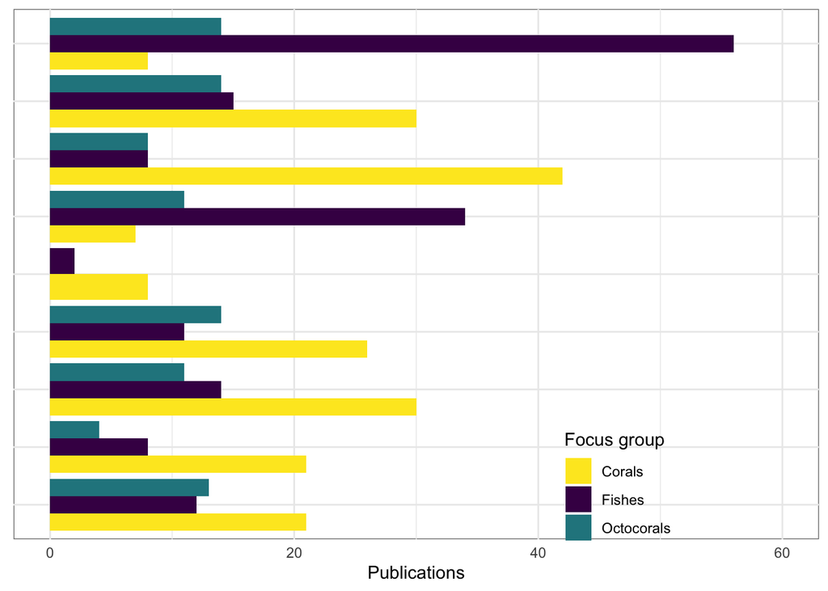

```r
#publs_fields_CoralFishOctocoral$focusgroups <- recode(publs_fields_CoralFishOctocoral$focusgroups, 'Algae (Macro, Turf and Crustose Coralline)' = "Macroalgae")

publs_fields_CoralFishOctocoral$focusgroups <- recode(publs_fields_CoralFishOctocoral$focusgroups, 'Octocorallia (Soft Corals)' = "Octocorals")

#publs_fields_CoralFishOctocoral$focusgroups <- recode(publs_fields_CoralFishOctocoral$focusgroups, 'Porifera (Sponges)' = "Sponges")

publs_fields_CoralFishOctocoral$focusgroups <- recode(publs_fields_CoralFishOctocoral$focusgroups, 'Scleractinia (Hard Corals)' = "Corals")

publs_fields_CoralFishOctocoral$focusgroups <- factor(publs_fields_CoralFishOctocoral$focusgroups, levels = c("Octocorals", "Fishes", "Corals"))

barplot_fields <- publs_fields_CoralFishOctocoral %>%
  filter(fields == "Taxonomy" | fields == "Molecular ecology" | fields == "Physiology" | fields == "Management and Conservation" | fields == "Geomorphology" | fields == "Disturbances" | fields == "Connectivity" | fields == "Long-term monitoring" | fields == "Reproduction") %>%
  group_by(fields, focusgroups) %>%
      dplyr::summarise(count=n()) %>%
        ggplot(aes(x = count, y = fields, fill = str_wrap(focusgroups))) +
          geom_bar(stat="identity", position="dodge") + #, fill = "grey"
          #theme(axis.text.x = element_text(angle = 90, hjust = 1)) +
          #scale_fill_viridis(discrete=TRUE, name="") +
          scale_fill_manual("Focus group", values=c("#fde725", "#440154", "#25858EFF")) +
          scale_x_continuous(limits = c(0, 60)) +
          xlab("Publications") +
          #ylab("") +
          #labs(x = "Percent", y = "Fields", title = "TME") +
           theme_minimal() +
           theme(panel.background = element_rect(colour = "grey50"), axis.text.y=element_blank(), axis.title.y=element_blank(), legend.position = c(.75,.1))
#legend.position = c(.7,.05)
#legend.position = c(.8,.2)
#legend.key.height = unit(1, "null"),
#, legend.title = element_text(size = 6), legend.text = element_text(size = 6)

# legend.key.width = unit(5, "null"),
# By setting the legend.key{.height/.width} theme argument as a "null" unit, legends can now expand to fill the available space.

barplot_fields
```

Break out into top focusgroups - Scleractinian corals, Fishes, Octocorallia

merge ridgeline with barplot counts

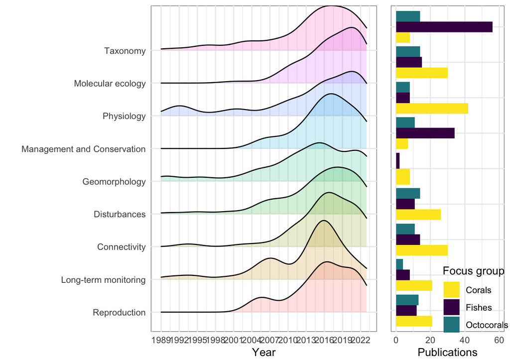

```r
# cowplot

#pdf("Fig Fields emerging rideplot barplot combo_focusgroups_07-28.pdf", width = 8, height = 6, encoding="MacRoman") #width = 10

plot <- plot_grid(ridgeplot_fields,
                  barplot_fields,
                  #labels = c('a)', 'b)', 'c)', 'd)'),
                  #hjust = -1,
                  #vjust = 1,
                  #align = "hv",
                  rel_widths = c(3, 1),
                  rel_heights = 1,
                  #scale = c(1, 1. 1, 1),
                  label_size = 12,
                  ncol = 2,
                  label_fontface = "plain")
plot
```

```r
#dev.off()

#svg("Fig Fields emerging rideplot barplot combo_focusgroups_07-28.svg", width = 8, height = 6)
#print(plot)
#dev.off()
```

Alternate ridgeline b with barplot counts

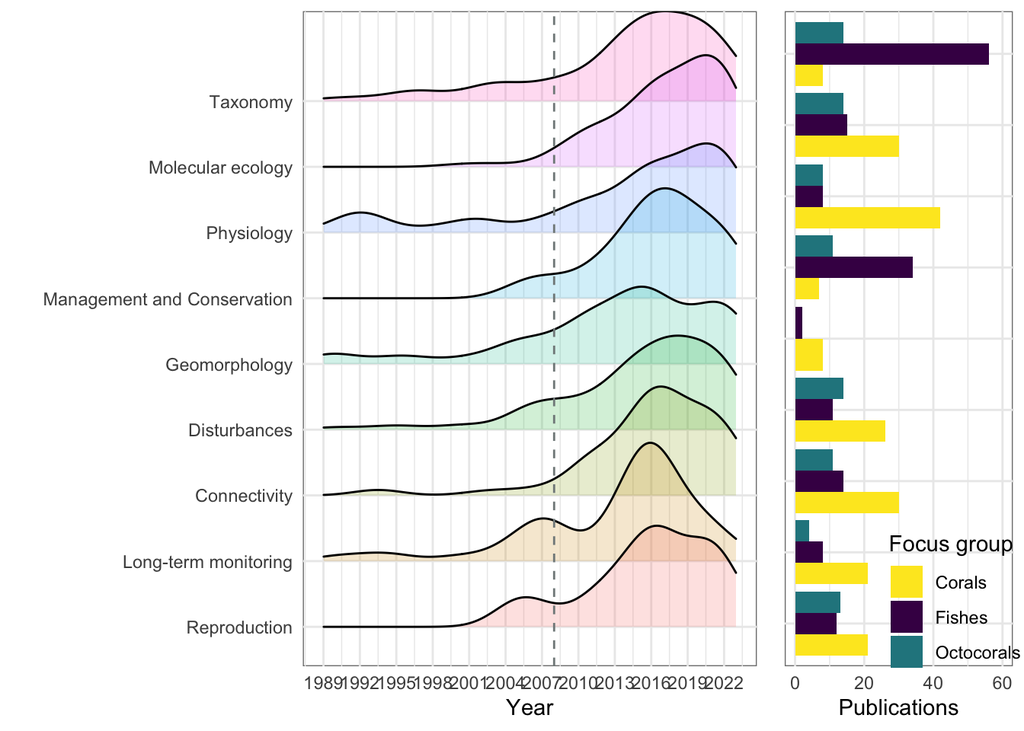

```r
# cowplot

#pdf("Fig Fields emerging rideplot barplot combo_focusgroups_07-28_ALT-2008-vline.pdf", width = 8, height = 6, encoding="MacRoman") #width = 10

plot <- plot_grid(ridgeplot_fields_b,
                  barplot_fields,
                  #labels = c('a)', 'b)', 'c)', 'd)'),
                  #hjust = -1,
                  #vjust = 1,
                  #align = "hv",
                  rel_widths = c(3, 1),
                  rel_heights = 1,
                  #scale = c(1, 1. 1, 1),
                  label_size = 12,
                  ncol = 2,
                  label_fontface = "plain")
plot
```

```r
#dev.off()

#svg("Fig Fields emerging rideplot barplot combo_focusgroups_07-28_ALT-2008-vline.svg", width = 8, height = 6)

ggsave(plot, file="Fig Fields emerging rideplot barplot combo_focusgroups_Final.pdf", width = 8, height = 6, dpi = 150, units = "in", device="pdf")
#ggsave(plot, file="Fig Fields emerging rideplot barplot combo_focusgroups_Final.eps", width = 8, height = 6, dpi = 150, units = "in", device="eps")
#ggsave(plot, file="Fig Fields emerging rideplot barplot combo_focusgroups_Final.jpg", width = 8, height = 6, dpi = 150, units = "in", device="jpg")
#ggsave(plot, file="Fig Fields emerging rideplot barplot combo_focusgroups_Final.tiff", width = 8, height = 6, dpi = 150, units = "in", device="tiff")

#print(plot)
#dev.off()
```

## Publications by ‘Platforms’

```r
# Split `platforms` into new rows
publs_platforms <- separate_rows(publs, "platforms", sep=";\\s+") #publs_for_stats

# Remove rows with no associated `platforms`
publs_platforms <- publs_platforms[!
(is.na(publs_platforms$platforms) |
publs_platforms$platforms ==
""), ]

publs_platforms$platforms <- factor(publs_platforms$platforms)

#write.csv(publs_platforms, "publs_platforms.csv")
```

```r
publs_platforms %>%
     group_by(platforms) %>%
      dplyr::summarise(count=n()) %>%
        arrange(desc(count))
```

```
## # A tibble: 17 × 2
##    platforms                             count
##    <fct>                                 <int>
##  1 SCUBA (open-circuit or unspecified)     577
##  2 Remotely Operated Vehicle (ROV)         281
##  3 Manned Submersible                      185
##  4 Rebreather                              171
##  5 Sonar / Multibeam                        97
##  6 Dredging / trawling                      68
##  7 Surface-deployed sensors and samplers    64
##  8 Drop / Towed Video                       59
##  9 In-situ instrumentation                  49
## 10 Land-based                               45
## 11 Fishing                                  42
## 12 Baited Remote Underwater Video (BRUV)    40
## 13 Autonomous Underwater Vehicle (AUV)      36
## 14 Aquarium-based                           32
## 15 Acoustic Telemetry                       24
## 16 Coring / drilling                        24
## 17 Snorkeling                               16
```

### Platforms by Location

```r
# Split `locations` into new rows
publs_platforms_location <- separate_rows(publs_platforms, "locations", sep=";\\s+") #publs_for_stats

# Remove rows with no associated `locations`
publs_platforms_location <- publs_platforms_location[!
(is.na(publs_platforms_location$locations) |
publs_platforms_location$locations ==
""), ]

publs_platforms_location$locations <- factor(publs_platforms_location$locations)

#write.csv(publs_platforms_location, "publs_platforms_location.csv")
```

```r
publs_platforms_location %>%
  filter(platforms == "Manned Submersible") %>%
    group_by(locations) %>%
      dplyr::summarise(count=n()) %>%
        #top_n(10, count) %>%
          arrange(desc(count))
```

```
## # A tibble: 56 × 2
##    locations                        count
##    <fct>                            <int>
##  1 USA - Hawaii                        47
##  2 Bahamas                             26
##  3 Curaçao                             22
##  4 Israel - Red Sea                    11
##  5 USA - Continental Atlantic Ocean    11
##  6 Bermuda                             10
##  7 Bonaire                              8
##  8 Costa Rica - Pacific Ocean           8
##  9 Jamaica                              8
## 10 USA - Continental Pacific Ocean      8
## # ℹ 46 more rows
```

```r
publs_platforms_location %>%
  filter(platforms == "Rebreather") %>%
    group_by(locations) %>%
      dplyr::summarise(count=n()) %>%
        #top_n(10, count) %>%
          arrange(desc(count))
```

```
## # A tibble: 60 × 2
##    locations                               count
##    <fct>                                   <int>
##  1 Puerto Rico                                29
##  2 USA - Hawaii                               24
##  3 Israel - Red Sea                           20
##  4 Bermuda                                    10
##  5 US Virgin Islands                          10
##  6 Bahamas                                     9
##  7 Italy - Ligurian-Tyrrhenian                 9
##  8 Micronesia - Caroline Islands (Pohnpei)     9
##  9 Cayman Islands                              8
## 10 French Polynesia                            8
## # ℹ 50 more rows
```

Platforms used by location - organized by platform

```r
publs_platforms_location_counts <- publs_platforms_location %>%
    group_by(platforms, locations) %>%
      dplyr::summarise(count=n()) %>%
        #top_n(15, count) %>%
          arrange(desc(count))
head(publs_platforms_location_counts)
```

```
## # A tibble: 6 × 3
## # Groups:   platforms [3]
##   platforms                           locations                   count
##   <fct>                               <fct>                       <int>
## 1 SCUBA (open-circuit or unspecified) Israel - Red Sea               60
## 2 Remotely Operated Vehicle (ROV)     Italy - Ligurian-Tyrrhenian    50
## 3 Manned Submersible                  USA - Hawaii                   47
## 4 SCUBA (open-circuit or unspecified) Italy - Ligurian-Tyrrhenian    47
## 5 SCUBA (open-circuit or unspecified) USA - Hawaii                   47
## 6 SCUBA (open-circuit or unspecified) US Virgin Islands              34
```

top 10

```r
publs_platforms_location %>%
    group_by(platforms, locations) %>%
      dplyr::summarise(count=n()) %>%
        top_n(10, count) %>%
          arrange(desc(count)) %>%
            head()
```

```
## # A tibble: 6 × 3
## # Groups:   platforms [3]
##   platforms                           locations                   count
##   <fct>                               <fct>                       <int>
## 1 SCUBA (open-circuit or unspecified) Israel - Red Sea               60
## 2 Remotely Operated Vehicle (ROV)     Italy - Ligurian-Tyrrhenian    50
## 3 Manned Submersible                  USA - Hawaii                   47
## 4 SCUBA (open-circuit or unspecified) Italy - Ligurian-Tyrrhenian    47
## 5 SCUBA (open-circuit or unspecified) USA - Hawaii                   47
## 6 SCUBA (open-circuit or unspecified) US Virgin Islands              34
```

## Publications by ‘Locations’

##### Consider MCE and TME separately

MCE - publications that only had MCE locations

```r
publs.mce <- subset(publs, mce == "TRUE" & tme == "FALSE") #mce == "true" & tme == "false"
publs.mce <- droplevels(publs.mce)
```

```r
# Split `locations` into new rows
publs.mce_locations <- separate_rows(publs.mce, "locations", sep=";\\s+") #publs_for_stats

# Remove rows with no associated `locations`
publs.mce_locations <- publs.mce_locations[!
(is.na(publs.mce_locations$locations) |
publs.mce_locations$locations ==
""), ]

publs.mce_locations$locations <- factor(publs.mce_locations$locations)
```

```r
n_distinct(publs.mce_locations$locations)
```

```
## [1] 110
```

```r
#unique(publs.mce_locations$locations)
```

```r
#Separate by periods, unp until 2008 and 2009-2023
publs.mce_locations$range <- ifelse(publs.mce_locations$publication_year <= 2008, '<2008',
                       ifelse(publs.mce_locations$publication_year <=2023, '<2023', 'unassigned'))
```

```r
publs.mce_locations %>%
  group_by(range) %>%
    dplyr::summarise(count=n())
```

```
## # A tibble: 2 × 2
##   range count
##   <chr> <int>
## 1 <2008   286
## 2 <2023   855
```

```r
#before 2008
publs_mce_2008 <- subset(publs.mce_locations, range == "<2008")
publs_mce_2008 <- droplevels(publs_mce_2008)
n_distinct(publs_mce_2008$locations)
```

```
## [1] 66
```

```r
publs_mce_2008 %>%
  group_by(locations) %>%
    dplyr::summarise() %>% #dplyr::summarise(count=n())
      head()
```

```
## # A tibble: 6 × 1
##   locations
##   <fct>
## 1 American Samoa
## 2 Aruba
## 3 Australia - Coral Sea
## 4 Australia - Great Barrier Reef
## 5 Australia - Northern Australia
## 6 Bahamas
```

```r
#2009-2023
publs_mce_2023 <- subset(publs.mce_locations, range == "<2023")
publs_mce_2023 <- droplevels(publs_mce_2023)
n_distinct(publs_mce_2023$locations)
```

```
## [1] 97
```

```r
publs_mce_2023 %>%
  group_by(locations) %>%
    dplyr::summarise() %>% #dplyr::summarise(count=n())
      head()
```

```
## # A tibble: 6 × 1
##   locations
##   <fct>
## 1 American Samoa
## 2 Aruba
## 3 Australia - Coral Sea
## 4 Australia - Great Barrier Reef
## 5 Australia - Northern Australia
## 6 Australia - Scott Reef
```

*However, there is overlap of locations that are present in both Before 2008 and 2009-2023 data*

*Cross check to only obtain unique locations*

Grand total = 13 unique locations Before 2008 + 53 shared locations two time periods + 44 new MCE locations 2008-2023 + 1 La Perouse* + 1 Singapore* = TOTAL 112 unique MCE locations

*La Perouse (publication 1642 - had both MCE and TME tags, but manually reviewed and it is a valid new location in 2023)* Singapore (often without “mesophotic” tag because research at shallow depths, but included in database because low-light reef environment is relevant to mesophotic science)

```r
#find duplicates between two data frames
dplyr::intersect(publs_mce_2008$locations, publs_mce_2023$locations)
```

```
##  [1] "USA - Johnston Atoll"
##  [2] "Micronesia - Marshall Islands"
##  [3] "Curaçao"
##  [4] "Bonaire"
##  [5] "Brazil - Eastern Brazil"
##  [6] "Bahamas"
##  [7] "Barbados"
##  [8] "Belize"
##  [9] "Bermuda"
## [10] "Cuba"
## [11] "Dominica"
## [12] "Honduras - Bay Islands"
## [13] "Puerto Rico"
## [14] "US Virgin Islands"
## [15] "Trinidad and Tobago"
```

[output cut: 38 more lines]

Number of publications per location

```r
publs.mce_locations_counts <- publs.mce_locations %>%
  group_by(locations) %>%
    dplyr::summarise(count=n()) %>%
      arrange(count)

publs.mce_locations_counts
```

```
## # A tibble: 110 × 2
##    locations                           count
##    <fct>                               <int>
##  1 Brunei                                  1
##  2 Cape Verde                              1
##  3 Christmas Island                        1
##  4 Clipperton Island                       1
##  5 Colombia - Pacific Ocean                1
##  6 Djibouti                                1
##  7 Dominican Republic                      1
##  8 French Guiana                           1
##  9 Grenada                                 1
## 10 India - Andaman and Nicobar Islands     1
## # ℹ 100 more rows
```

```r
write.csv(publs.mce_locations_counts, "publs.mce_locations_counts.csv")
```

#### TME - publications that only had TME locations

```r
publs.tme <- subset(publs, tme == "TRUE" & mce == "FALSE") #tme == "true" & mce == "false"
publs.tme <- droplevels(publs.tme)
```

```r
# Split `locations` into new rows
publs.tme_locations <- separate_rows(publs.tme, "locations", sep=";\\s+") #publs_for_stats

# Remove rows with no associated `locations`
publs.tme_locations <- publs.tme_locations[!
(is.na(publs.tme_locations$locations) |
publs.tme_locations$locations ==
""), ]

publs.tme_locations$locations <- factor(publs.tme_locations$locations)
```

```r
n_distinct(publs.tme_locations$locations)
```

```
## [1] 42
```

```r
#unique(publs.tme_locations$locations)
```

```r
#Separate by periods, up until 2008 and 2009-2023
publs.tme_locations$range <- ifelse(publs.tme_locations$publication_year <= 2008, '<2008',
                       ifelse(publs.tme_locations$publication_year <=2023, '<2023', 'unassigned'))
```

```r
publs.tme_locations %>%
  group_by(range) %>%
    dplyr::summarise(count=n())
```

```
## # A tibble: 2 × 2
##   range count
##   <chr> <int>
## 1 <2008    48
## 2 <2023   300
```

```r
#before 2008
publs_tme_2008 <- subset(publs.tme_locations, range == "<2008")
publs_tme_2008 <- droplevels(publs_tme_2008)
n_distinct(publs_tme_2008$locations)
```

```
## [1] 19
```

*1 unique location from before 2008 (“Mexico - Baja California”)*

```r
#2009-2023
publs_tme_2023 <- subset(publs.tme_locations, range == "<2023")
publs_tme_2023 <- droplevels(publs_tme_2023)
n_distinct(publs_tme_2023$locations)
```

```
## [1] 41
```

In summary, 18 TME locations were both in Before 2008 and 2008-2023 categories Therefore 41 new locations 2008-2023 - 18 shared locations = 23 new TME locations between 2008-2023

Therefore, 1 unique Before 2008 locations + 18 shared locations two time periods + 23 new 2008-2023 locations = 42 locations total

```r
#find duplicates between two data frames
dplyr::intersect(publs_tme_2008$locations, publs_tme_2023$locations)
```

```
##  [1] "USA - Continental Pacific Ocean"    "Spain - Mediterranean Sea"
##  [3] "Denmark"                            "USA - Continental Atlantic Ocean"
##  [5] "Italy - Ligurian-Tyrrhenian"        "Greece"
##  [7] "South Africa"                       "Australia - Southeastern Australia"
##  [9] "Turkey - Mediterranean Sea"         "Italy - Mediterranean"
## [11] "France - Mediterranean Sea"         "Italy - Adriatic-Ionian"
## [13] "New Zealand"                        "Canada - Atlantic Ocean"
## [15] "Scotland"                           "Spain - Canary Islands"
## [17] "Belgium"                            "Canada - British Columbia"
```

Number of publications per location

```r
publs.tme_locations_counts <- publs.tme_locations %>%
  group_by(locations) %>%
    dplyr::summarise(count=n()) %>%
      arrange(count)

publs.tme_locations_counts
```

```
## # A tibble: 42 × 2
##    locations                count
##    <fct>                    <int>
##  1 Albania                      1
##  2 Cyprus                       1
##  3 Ireland                      1
##  4 Japan                        1
##  5 Lebanon                      1
##  6 Malta                        1
##  7 Mexico - Baja California     1
##  8 Montenegro                   1
##  9 Morocco                      1
## 10 Netherlands                  1
## # ℹ 32 more rows
```

```r
write.csv(publs.tme_locations_counts, "publs.tme_locations_counts.csv")
```

### Overall locations

```r
# Split `locations` into new rows
publs_locations <- separate_rows(publs, "locations", sep=";\\s+") #publs_for_stats

# Remove rows with no associated `locations`
publs_locations <- publs_locations[!
(is.na(publs_locations$locations) |
publs_locations$locations ==
""), ]

publs_locations$locations <- factor(publs_locations$locations)
```

```r
#Separate by periods, before 2008 and 2009-2023
publs_locations$range <- ifelse(publs_locations$publication_year <= 2008, '<2008',
                       ifelse(publs_locations$publication_year <=2023, '<2023', 'unassigned'))
```

```r
#before 2008
publs_2008 <- subset(publs_locations, range == "<2008")
n_distinct(publs_2008$locations)
```

```
## [1] 85
```

```r
#2009-2023
publs_2023 <- subset(publs_locations, range == "<2023")
n_distinct(publs_2023$locations)
```

```
## [1] 138
```

```r
publs_locations %>%
    group_by(locations) %>%
      dplyr::summarise(count=n()) %>%
        #top_n(10, count) %>%
          arrange(desc(count))
```

```
## # A tibble: 151 × 2
##    locations                      count
##    <fct>                          <int>
##  1 USA - Hawaii                     103
##  2 Israel - Red Sea                  95
##  3 Italy - Ligurian-Tyrrhenian       95
##  4 Puerto Rico                       58
##  5 US Virgin Islands                 53
##  6 USA - Gulf of Mexico              50
##  7 Curaçao                           49
##  8 Brazil - Eastern Brazil           47
##  9 Spain - Mediterranean Sea         45
## 10 Australia - Great Barrier Reef    43
## # ℹ 141 more rows
```

```r
publs_locations <- subset(publs_locations, original_data == "TRUE") #original_data == "true"

write.csv(publs_locations, "publs_locations_scientific_articles_original-data.csv")
```